# Smoothing, derivatives, and continuum removal

Jose Eduardo Meireles

July 2026

This vignette covers `spectrolab`’s spectral preprocessing tools: smoothing (including a Savitzky-Golay filter), spectral derivatives, and continuum removal. All of them are transform functions – they take a `spectra` object and return one – and all of them **require strictly increasing bands** (splice sensor overlaps with `match_sensors()` first if needed; see the Matching sensor overlap vignette).

```r
library(spectrolab)

spec = as_spectra(spec_matrix_example, name_idx = 1)
one  = spec[1, ]   # a single spectrum, used for the "before/after" plots below
```

## Smoothing

`smooth()` dispatches to four methods via its `method` argument:

| `method` | function | idea |
| --- | --- | --- |
| `"gaussian"` (default) | `smooth_fwhm()` | resample onto the same bands using a wider Gaussian FWHM (see the Resampling Spectra vignette) |
| `"spline"` | `smooth_spline()` | fit `stats::smooth.spline()` per sample |
| `"moving_average"` | `smooth_moving_avg()` | simple moving average over `n` adjacent bands |
| `"sgolay"` | `smooth_sgolay()` | Savitzky-Golay filter: a local polynomial fit over a moving window (requires the `signal` package) |

```r
s_gauss = smooth(one, method = "gaussian")
```

```
#> setting k to the number of unique band diff values
```

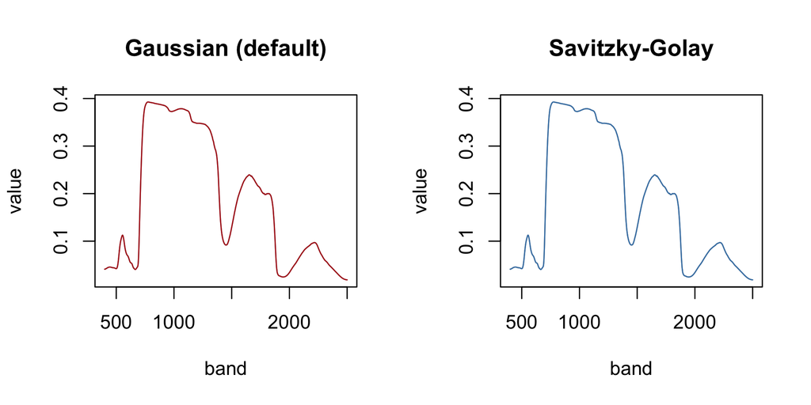

```r
s_sg    = suppressMessages(smooth(one, method = "sgolay"))

oldpar = par(no.readonly = TRUE)
par(mfrow = c(1, 2))

plot(one, lwd = 1, col = "grey60", main = "Gaussian (default)")
plot(s_gauss, add = TRUE, col = "firebrick", lwd = 1)

plot(one, lwd = 1, col = "grey60", main = "Savitzky-Golay")
plot(s_sg, add = TRUE, col = "steelblue", lwd = 1)
```

```r
par(oldpar)
```

### The Savitzky-Golay filter in more detail

`smooth_sgolay(x, p, n)` fits a degree-`p` polynomial over a moving window of `n` bands and replaces the center value with the fitted one. `n` must be odd and greater than `p`; the default, `n = p + 3 - p %% 2`, is deliberately small (5 bands, for the default `p = 3`) so it does very little smoothing until you widen the window:

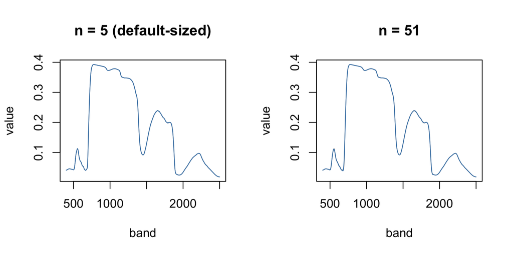

```r
s_narrow = smooth_sgolay(one, p = 3, n = 5)    # default-sized window
s_wide   = smooth_sgolay(one, p = 3, n = 51)   # a much wider window

oldpar = par(no.readonly = TRUE)
par(mfrow = c(1, 2))

plot(one, lwd = 1, col = "grey60", main = "n = 5 (default-sized)")
plot(s_narrow, add = TRUE, col = "steelblue", lwd = 1)

plot(one, lwd = 1, col = "grey60", main = "n = 51")
plot(s_wide, add = TRUE, col = "steelblue", lwd = 1)
```

```r
par(oldpar)
```

Unlike a simple moving average, the Savitzky-Golay filter has full-length output at the edges (no bands are dropped there) because its polynomial fit is defined at every point in the window, including the boundary – see the Gotchas below for how `smooth_moving_avg()` differs.

## Spectral derivatives

`deriv_spectra(x, order)` computes the order-`order` derivative of each spectrum using the same Savitzky-Golay machinery (also requires `signal`). Derivatives are a classic way to emphasize subtle inflection points – like the position of the red edge – that are hard to see in raw reflectance.

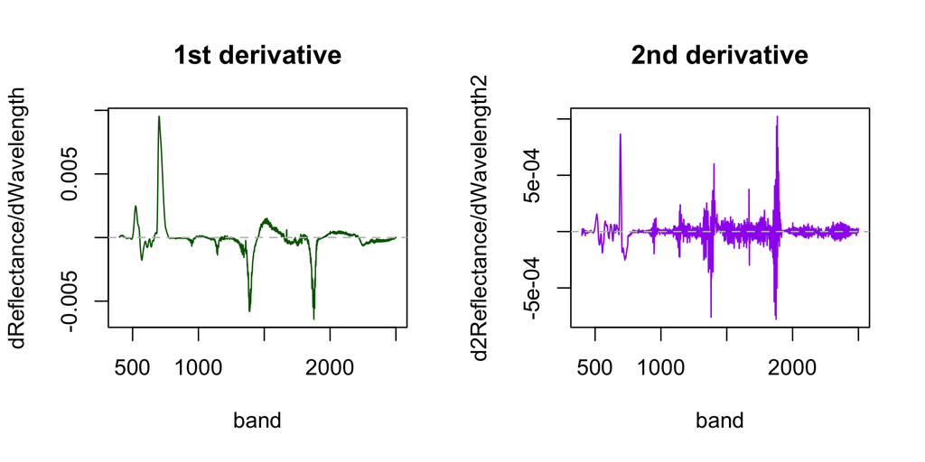

```r
d1 = suppressMessages(deriv_spectra(one, order = 1))
d2 = suppressMessages(deriv_spectra(one, order = 2))

oldpar = par(no.readonly = TRUE)
par(mfrow = c(1, 2))

plot(d1, main = "1st derivative", col = "darkgreen", ylab = "dReflectance/dWavelength")
abline(h = 0, col = "grey", lty = 2)

plot(d2, main = "2nd derivative", col = "purple", ylab = "d2Reflectance/dWavelength2")
abline(h = 0, col = "grey", lty = 2)
```

```r
par(oldpar)
```

`deriv_spectra()` (like `smooth_sgolay()`) emits a message reminding you that the output is **no longer reflectance/radiance** – the y-axis units have changed. Pass `quiet = TRUE` once you know that.

## Continuum removal

The “continuum” of a spectrum is its upper convex hull in wavelength/value space – essentially the smooth envelope you’d draw connecting the local reflectance peaks. Dividing a spectrum by its continuum, `continuum_removal()`, suppresses broad absorption features and emphasizes the depth of local ones (a standard technique in mineral and vegetation spectroscopy for comparing absorption features across samples that otherwise differ in overall brightness/albedo).

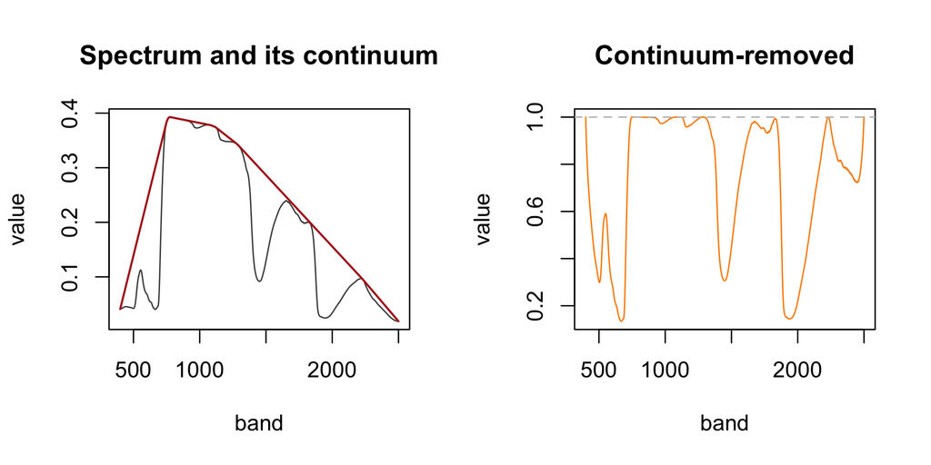

```r
one_cr = continuum_removal(one)

# Compute the hull the same way continuum_removal() does internally, purely
# to visualize it -- this is NOT required to use continuum_removal() itself.
w = bands(one)
r = as.numeric(value(one))
h = grDevices::chull(w, r)
chord = r[[1]] + (r[[length(r)]] - r[[1]]) * (w[h] - w[[1]]) / (w[[length(w)]] - w[[1]])
h = sort(h[r[h] >= chord - sqrt(.Machine$double.eps)])
hull = stats::approx(w[h], r[h], xout = w)$y

oldpar = par(no.readonly = TRUE)
par(mfrow = c(1, 2))

plot(one, lwd = 1, col = "grey30", main = "Spectrum and its continuum")
lines(w, hull, col = "firebrick", lwd = 1.5)

plot(one_cr, lwd = 1, col = "darkorange", main = "Continuum-removed")
abline(h = 1, col = "grey", lty = 2)
```

```r
par(oldpar)
```

Continuum-removed values are always at or below 1 by construction (they are a spectrum divided by an envelope that sits at or above it everywhere), and they are, like derivatives, no longer reflectance.

## Gotchas

- **The `signal` package is required for `smooth_sgolay()` and `deriv_spectra()`**, but it’s only in `Suggests` – if it isn’t installed you’ll get a clear error telling you to install it, rather than a cryptic one.
- **The method name is `"sgolay"`**, not `"savitzky_golay"` or `"savgol"` – matching the naming used by the underlying `signal::sgolay()`/`sgolayfilt()` functions it wraps.
- **`smooth_moving_avg()` can silently drop bands.** Its moving average produces `NA` at the edges (there aren’t enough neighbors to average there), and those edge bands are then *removed* from the result – your output can have fewer bands than the input. The dropped values are stashed into metadata (`save_bands_to_meta = TRUE`, the default) so they aren’t lost, just relocated. `smooth_sgolay()` does not have this issue – its polynomial fit is defined at the edges too.
- **Derivative and continuum-removed values are not reflectance/radiance anymore.** Both `deriv_spectra()` and `continuum_removal()` clear the object’s `quantity()` to reflect that (see the Introduction vignette), but the values still happily flow into any function that doesn’t check `quantity()` itself (e.g. `normalize()`, the two-band spectral indices) – the attribute documents the change, it doesn’t block further processing.

```r
quantity(one) = "reflectance"
quantity(suppressMessages(deriv_spectra(one, order = 1)))
```

```
#> [1] NA
```

- **Choose the Savitzky-Golay window (`n`) relative to your spectral resolution**, not in the abstract: 5 bands means something very different on 1nm-resolution data than on 10nm data. The default is intentionally small; widen it deliberately, and check the result visually as we did above.